# Data Expo 2009: Airline on time data Flight Data Analysis 1987 to 2008

# Dataset overview

## Dataset overview

The original dataset contains around 120 million records for flights from 1987 to 2008, however, the following presentation is utilizing a curated sample dataset that is composed of 5 million records.

The sample dataset includes attributes that will be discussed in this presentation like Flight name, Airline name, Actual departure time, Actual arrival time and Date.

# Investigation overview

## Investigation overview

The analysis process will focus on trivial questions, as the presentation progress, we will be answering more complex questions.

Some of these questions are:

- Which year was the busiest for flights ?
- Which month was the busiest for flights ?
- What is the relation between Departure and Arrival Delay?
- How Does progression of time relate to Departure and Arrival Delay?

and more .......

## Which year was the busiest for flights from 1987 to 2008 ?

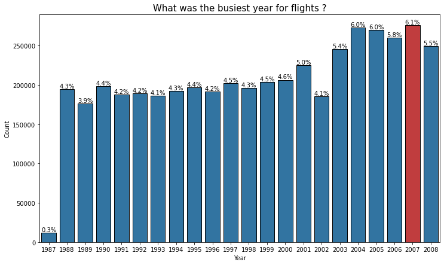

```python
plt.figure(figsize=(12,7))
colors = [base_color if (x < Year_counts.max()) else alt for x in Year_counts ]
sns.barplot(x=Year_counts.index,y=Year_counts, palette=colors,edgecolor='black');
plt.xlabel('Year')
plt.ylabel('Count')
plt.title('What was the busiest year for flights ?',size=15)

for i in range (Year_counts.shape[0]):
    plt.text(i,
             Year_counts.values[i],
             year_text[i],
             ha='center',
             va='bottom')
```

> 2007 was the busiest year for flights.

## Which month was the busiest for flights from 1987 to 2008 ?

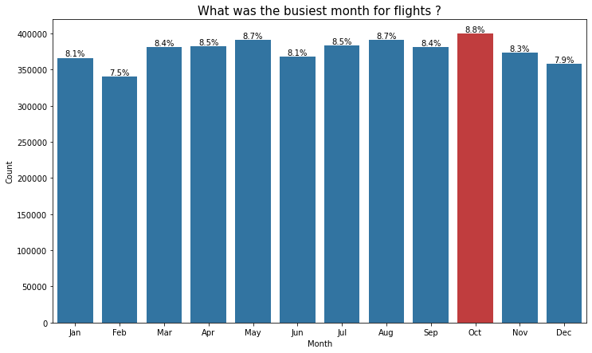

```python
plt.figure(figsize=(12,7))
colors = [base_color if (x < Month_counts.max()) else alt for x in Month_counts ]
sns.barplot(x=Month_counts.index,y=Month_counts, palette=colors);
plt.xlabel('Month')
plt.xticks(ticks=[0,1,2,3,4,5,6,7,8,9,10,11],
           labels=['Jan','Feb','Mar','Apr','May','Jun','Jul','Aug','Sep','Oct','Nov','Dec'])
plt.ylabel('Count')
plt.title('What was the busiest month for flights ?',size=15)

for i in range (Month_counts.shape[0]):
    plt.text(i,
             Month_counts.values[i],
             Month_text[i],
             ha='center',
             va='bottom')
```

> October was the busiest month for flights.

## Which day was the busiest for flights from 1987 to 2008 ?

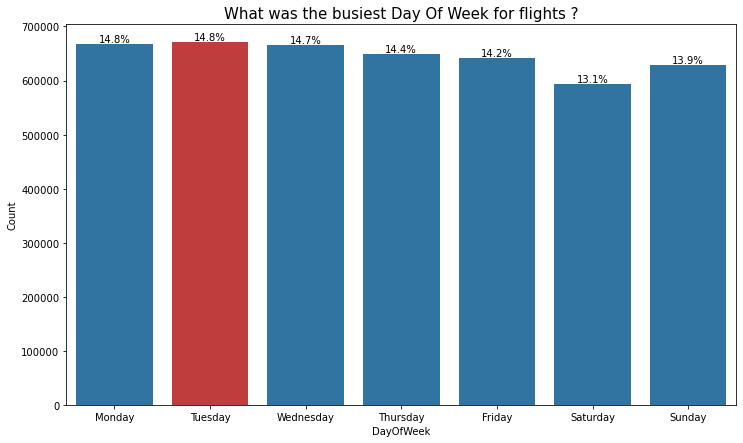

```python
plt.figure(figsize=(12,7))
colors = [base_color if (x < DayOfWeek_counts.max()) else alt for x in DayOfWeek_counts ]
sns.barplot(x=DayOfWeek_counts.index,y=DayOfWeek_counts, palette=colors);
plt.xlabel('DayOfWeek')
plt.xticks(ticks=[0,1,2,3,4,5,6],
           labels=['Monday','Tuesday','Wednesday','Thursday','Friday','Saturday','Sunday'])
plt.ylabel('Count')
plt.title('What was the busiest Day Of Week for flights ?',size=15)

for i in range (DayOfWeek_counts.shape[0]):
    plt.text(i,
             DayOfWeek_counts.values[i],
             DayOfWeek_text[i],
             ha='center',
             va='bottom')
```

> While the answer is Tuesday, It looks Monday and Wednesday also have similiar traffic, on the other hand Thursday, Friday and Saturday shows somewhat a gradual decrease compared to the 1st three days mentioned.

## What was the top 10 most frequent flights from 1987 to 2008?

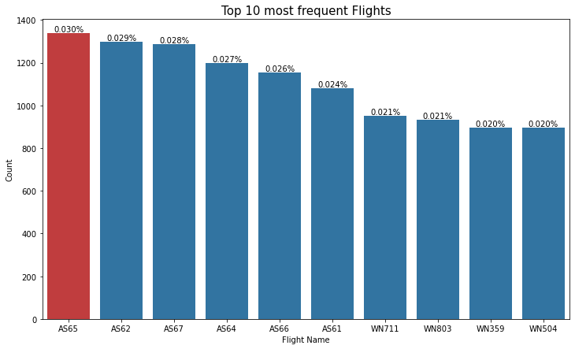

```python
plt.figure(figsize=(12,7))
colors = [base_color if (x < flight_counts.max()) else alt for x in flight_counts ]
sns.barplot(x=flight_counts.index,y=flight_counts,order=flight_counts.index, palette=colors);
plt.xlabel('Flight Name')
plt.ylabel('Count')
plt.title('Top 10 most frequent Flights',size=15)

for i in range (flight_counts.shape[0]):
    plt.text(i,
             flight_counts.values[i],
            flight_text[i],
             ha='center',
             va='bottom')
```

> In the top spot: Alaska Airlines flight number 65.  
> The top 6 most frequent flights go to Alaska Airlines.  
> The last 4 belong to Southwest Airlines.

## Is there a relation between Departure Delay and Arrival Delay ?

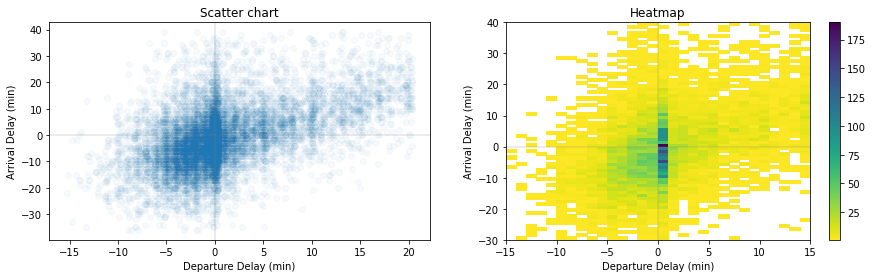

```python
fig=plt.figure(figsize=(15,4))

plt.subplot(1, 2, 1)
sns.regplot(data=fly.sample(10000), x='DepDelay', y ='ArrDelay',
            x_jitter=0.4, scatter_kws={'alpha':1/30},fit_reg= False);
plt.axhline(0,color=sns.color_palette()[7],lw=0.3)
plt.axvline(0,color=sns.color_palette()[7],lw=0.3)
plt.title('Scatter chart')
plt.xlabel('Departure Delay (min)')
plt.ylabel('Arrival Delay (min)')

plt.subplot(1, 2, 2)
bins_x = np.arange(-15, 15+1,1)
bins_y = np.arange(-30, 40+1, 1)
plt.hist2d(data = fly.sample(10000), x = 'DepDelay', y = 'ArrDelay',
            cmin=0.5, cmap='viridis_r',bins=[bins_x,bins_y])
plt.axhline(0,color=sns.color_palette()[7],lw=0.3)
plt.axvline(0,color=sns.color_palette()[7],lw=0.3)
plt.colorbar()
plt.title('Heatmap')
plt.xlabel('Departure Delay (min)')
plt.ylabel('Arrival Delay (min)');
```

> - The dark vertical plob of points means that flights departured on time, however variablity along y-axis at this specific vertical line shows a higher tendency to be "Early arrival" more than of the "Late Arrival".
> - In the third quadrant (lower left section) has higher concentration of points meaning, "Early departures are associated with "Early arrival"

## How does progression of time relate to Departure and Arrival Delays?

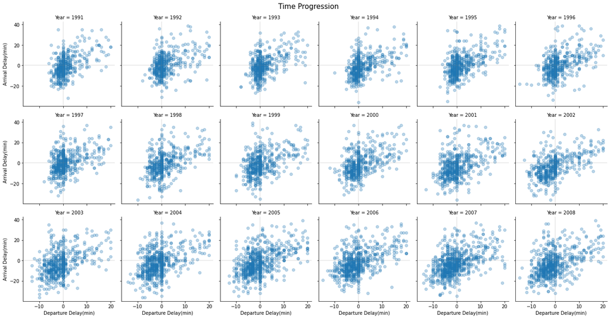

```python
g=sns.FacetGrid(data=fly[fly.Year>1990].sample(10000), col='Year',sharey=True,col_wrap=6)
g.set_axis_labels("Departure Delay(min)","Arrival Delay(min)");
g.map(plt.scatter,'DepDelay','ArrDelay',alpha=0.3);
g.map(plt.axhline,color='grey', y=0,lw=0.3);
g.map(plt.axvline,color='grey' ,x=0,lw=0.3);
plt.suptitle('Time Progression',va='bottom',size=15,y=1);
g.set_axis_labels("Departure Delay(min)","Arrival Delay(min)");
```

## Which Airline had most air-traffic from 1987 to 2008 ?

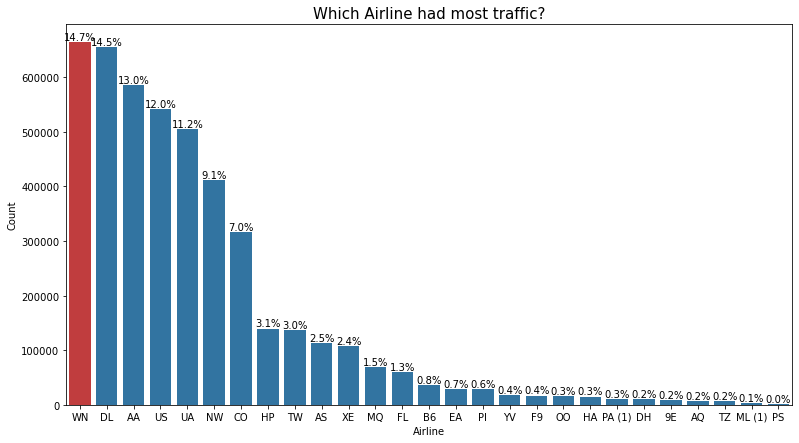

```python
plt.figure(figsize=(13,7))
colors = [base_color if (x < carrier_counts.max()) else alt for x in carrier_counts ]
sns.barplot(x=carrier_counts.index,y=carrier_counts,order=carrier_counts.index, palette=colors);
plt.xlabel('Airline')
plt.ylabel('Count')
plt.title('Which Airline had most traffic?',size=15)

for i in range (carrier_counts.shape[0]):
    plt.text(i,
             carrier_counts.values[i],
            carrier_text[i],
             ha='center',
             va='bottom')
```

> WN (Southwest Airlines) collectively had the highest air traffic from 1987 to 2008.  
> While the second place goes to DL (Delta Air Lines Inc.) with a slight relative difference.

## How bad was Departure delays through the years for the top 10 air-traffic Airlines ?

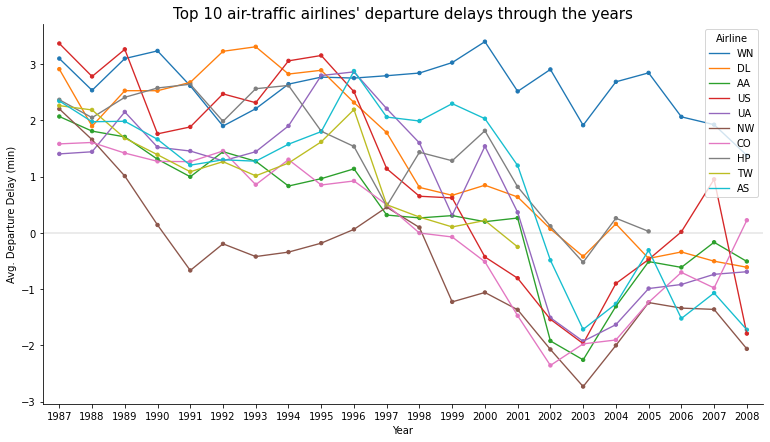

```python
g=sns.FacetGrid(data=top_fly,hue='UniqueCarrier',hue_order=top10car,height=6,aspect=1.8)
g.map(sns.pointplot,'Year','DepDelay',order=yearlist, ci=None, linestyles="-",scale=0.5)
plt.axhline(0,color=sns.color_palette()[7],lw=0.3)
plt.title("Top 10 air-traffic airlines' departure delays through the years",size=15)
plt.xlabel('Year')
plt.ylabel('Avg. Departure Delay (min)');
plt.legend(title='Airline',labels=top10car,loc='upper right');
```

> Around 2001 departure delays started to decrease, and by 2003 most of airlines on average had early departures.